# Homework 06

## Question 1: Compare KNN and logistic regression

Use breast-cancer.csv, which contains 569 cases from the [Wisconsin Diagnostic Breast Cancer dataset](https://archive.ics.uci.edu/dataset/17/breast%2Bcancer%2Bwisconsin%2Bdiagnostic). Predict `y` (1 for malignant and 0 for benign) using `mean_radius`, `mean_texture`, and `mean_smoothness`.

Set a random seed and randomly split the observations into 70% training and 30% test data. Use the same split for every model. Standardize the predictors using the training means and standard deviations, and apply the same transformations to the test data.

Fit ordinary logistic regression with an intercept and no penalty, and KNN with Euclidean distance, equal neighbor weights, and

$$k\in\{5,15,25,35,45\}.$$

Using the estimated probabilities for `y = 1` on the test data, plot all six ROC curves in one figure and report their AUC values. Which of the six fitted models do you prefer? Give a brief justification based on your results.

```
(398, 4) (171, 4)
Coefficients: [-1.17128623] [[5.32869966 1.78764003 2.14874951]]
```

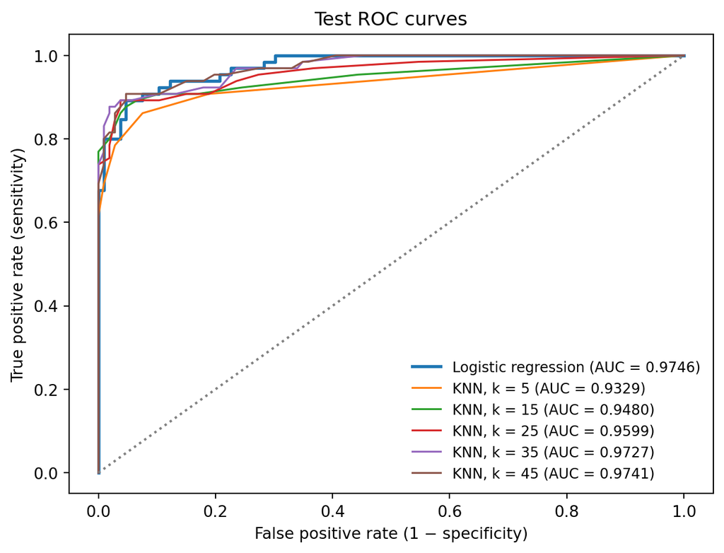

```
                 Model  Test AUC
0  Logistic regression    0.9746
1           KNN, k = 5    0.9329
2          KNN, k = 15    0.9480
3          KNN, k = 25    0.9599
4          KNN, k = 35    0.9727
5          KNN, k = 45    0.9741
```

```python
import numpy as np
import pandas as pd
import matplotlib.pyplot as plt
from sklearn.linear_model import LogisticRegression
from sklearn.neighbors import KNeighborsClassifier
from sklearn.metrics import roc_curve, roc_auc_score

# ---- Load data and use the course's train/test split ----
data  = pd.read_csv("data/breast-cancer.csv")
split = pd.read_csv("data/breast-cancer-split.csv")
train = data.loc[split["split"].eq("train")]
test  = data.loc[split["split"].eq("test")]
print(train.shape, test.shape)                     # (398, 4) (171, 4)

# ---- Standardize using TRAINING mean and sd ----
cols = ["mean_radius", "mean_texture", "mean_smoothness"]
mu, sd = train[cols].mean(), train[cols].std()
Xtr = ((train[cols] - mu) / sd).to_numpy()
Xte = ((test[cols]  - mu) / sd).to_numpy()
ytr, yte = train["y"].to_numpy(), test["y"].to_numpy()

# ---- Logistic regression (no penalty) ----
logit = LogisticRegression(C=np.inf, max_iter=1000).fit(Xtr, ytr)   # C = inf: no penalty
print("Coefficients:", logit.intercept_, logit.coef_)
probs = {"Logistic regression": logit.predict_proba(Xte)[:, 1]}   # P(malignant)

# ---- KNN, k = 5, 15, 25, 35, 45 (Euclidean, uniform weights) ----
for k in [5, 15, 25, 35, 45]:
    knn = KNeighborsClassifier(n_neighbors=k, weights="uniform",
                               metric="euclidean", algorithm="brute").fit(Xtr, ytr)
    probs[f"KNN, k = {k}"] = knn.predict_proba(Xte)[:, 1]

# ---- Test ROC curves and AUC ----
fig, ax = plt.subplots(figsize=(6.5, 5))
for name, p in probs.items():
    fpr, tpr, _ = roc_curve(yte, p)
    ax.plot(fpr, tpr, linewidth=2 if name.startswith("Logistic") else 1.2,
            label=f"{name} (AUC = {roc_auc_score(yte, p):.4f})")
ax.plot([0, 1], [0, 1], color="gray", linestyle=":")
ax.set_xlabel("False positive rate (1 − specificity)")
ax.set_ylabel("True positive rate (sensitivity)")
ax.set_title("Test ROC curves")
ax.legend(frameon=False, loc="lower right", fontsize=9)
fig.tight_layout()
plt.show()

auc_table = pd.DataFrame({"Model": list(probs.keys()),
                          "Test AUC": [roc_auc_score(yte, p) for p in probs.values()]})
print(auc_table.round(4))
```

The split file gives everyone the same 398 training and 171 test tumors. The three predictors are standardized with the training mean and sd, so radius (about 10–28) doesn’t dominate the KNN distances over smoothness (about 0.05–0.16). Each model outputs a probability that each test tumor is malignant. For logistic regression, that comes from the fitted model. For KNN, it’s the share of the k nearest training tumors that are malignant. The ROC curve tries every cutoff on those probabilities and plots how many malignant tumors are caught against how many benign ones are wrongly flagged. AUC sums the curve up in one number: the chance the model ranks a random malignant tumor above a random benign one. On this split, KNN’s test AUC rises with k, since more neighbors give smoother probabilities. That isn’t guaranteed in general, though: if k gets too large, KNN averages over distant tumors and misses local structure. I prefer logistic regression. It has the highest test AUC (0.9746) and it’s a simpler model, with three coefficients you can interpret. Its lead over KNN at k = 45 (0.9741) is tiny, though, so another split could flip the order.

## Question 2: Training and test ROC curves

Use the same data, training/test split, and standardization as in Question 1. Fit KNN with Euclidean distance, equal neighbor weights, and

$$k\in\{1,3,5,10,20\}.$$

Use each fitted model to estimate probabilities for both the training and test observations. For training predictions, include each observation itself among its $k$ nearest neighbors.

For each $k$, use a separate panel to show the training and test ROC curves together. Report both AUC values.

Explain the difference between training and test performance and how it changes with $k$. In particular, explain what happens at $k=1$ and why training performance may not reflect performance on new observations.

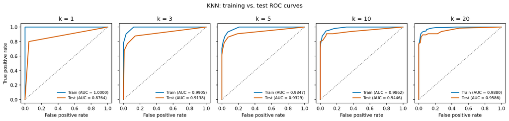

```
 k  Training AUC  Test AUC    Gap
 1        1.0000    0.8764 0.1236
 3        0.9905    0.9138 0.0768
 5        0.9847    0.9329 0.0518
10        0.9862    0.9446 0.0415
20        0.9880    0.9586 0.0294
```

```python
k_values = [1, 3, 5, 10, 20]
fig, axes = plt.subplots(1, 5, figsize=(15, 3.6), sharey=True)
rows = []

for ax, k in zip(axes, k_values):
    knn = KNeighborsClassifier(n_neighbors=k, weights="uniform",
                               metric="euclidean", algorithm="brute").fit(Xtr, ytr)

    # Training predictions: each point is its own nearest neighbor (distance 0)
    p_tr = knn.predict_proba(Xtr)[:, 1]
    p_te = knn.predict_proba(Xte)[:, 1]
    auc_tr = roc_auc_score(ytr, p_tr)
    auc_te = roc_auc_score(yte, p_te)
    rows.append({"k": k, "Training AUC": auc_tr, "Test AUC": auc_te, "Gap": auc_tr - auc_te})

    # One panel per k: training and test ROC together
    for y, p, lab, c in [(ytr, p_tr, f"Train (AUC = {auc_tr:.4f})", "#0072B2"),
                         (yte, p_te, f"Test (AUC = {auc_te:.4f})",  "#D55E00")]:
        fpr, tpr, _ = roc_curve(y, p)
        ax.plot(fpr, tpr, color=c, linewidth=1.8, label=lab)
    ax.plot([0, 1], [0, 1], color="gray", linestyle=":")
    ax.set_title(f"k = {k}")
    ax.set_xlabel("False positive rate")
    ax.legend(frameon=False, loc="lower right", fontsize=8)

axes[0].set_ylabel("True positive rate")
fig.suptitle("KNN: training vs. test ROC curves")
fig.tight_layout()
plt.show()

print(pd.DataFrame(rows).round(4).to_string(index=False))
```

Training AUC is higher than test AUC for every k, because each training point is part of its own neighborhood. The model has already “seen the answer” for those points. At k = 1 this is extreme. The single nearest neighbor of every training point is the point itself, so its predicted probability is just its own label (0 or 1). That gives a perfect training AUC of 1.0000. The model has memorized the training set; it hasn’t learned the pattern. On new tumors, a single neighbor is noisy, so test AUC is only 0.8764, and the probabilities can only be 0 or 1, which is why the test ROC curve has only one point between (0, 0) and (1, 1) and is drawn as two straight line segments. As k grows, the point’s own label becomes a smaller share of the vote: 1/3, then 1/5, and so on down to 1/20. Training AUC stays near 0.98–0.99, but the training advantage shrinks: test AUC rises steadily to 0.9586, and the gap drops from 0.124 to 0.029. The takeaway is that training performance, especially for flexible models like small-k KNN, can be overly optimistic. You need held-out test data to judge how a model will do on new observations.

## Question 3: Peer evaluation of Homework 5

You will receive two Homework 5 submissions to review. The instructor’s GitHub account, **rqzhu-aide**, will open a **GitHub Issue** in the repository containing your Homework 5 submission. It will contain links to two other students’ repositories, where you can find their submitted homework reports.

Open your repository’s **Issues** tab on GitHub to find the assignment. You may ask AI to explain GitHub Issues or help you locate the assignment.

Choose **one specific mistake or item for improvement** from any question in either report.

1. **Identify the mistake or item for improvement.** State which report and question you selected, and briefly describe what is wrong or could be improved. Examples include incorrect code, a calculation error, a misinterpretation of results, a plot that could communicate the findings more clearly, or anything else you think could be done better.
2. **Explain your assessment.** Quote the relevant text, code, or figure caption exactly. Explain why the selected answer is incorrect or how it could be improved, referring to its reasoning, calculations, code, figures, or interpretation. **Complete this part yourself, without AI assistance.**
3. **Provide a correction.** Write a corrected or improved answer to the selected question, including any calculations, code, or figures needed.

After completing your review, **open a GitHub Issue in the repository containing the report you selected**. Identify the report and question, and include your assessment and a detailed revision plan explaining what the author should change and why. Include a link to your posted GitHub Issue in your Homework 6 answer.

### Selected mistake

**Report:** gaoxinc2, Homework 5, Question 4c ([report](https://github.com/gaoxinc2/stat432-fall2026/blob/main/homework/week-05/homework-05.html)).

The code that displays the three misclassified test images sets the color scale to `vmin=0, vmax=1`, but the pixel values in the zip data range from −1 to 1.

### Assessment

In the original code’s plotting code, the image are drawn with

```python
    plt.imshow(
        image,
        cmap="gray_r",
        vmin=0,
        vmax=1
    )
```

The zip pixel values range from −1 to 1, so using `vmin=0` clips all negative values to white (the same as the background). This makes the image appear thinner as the faint edges of each stroke disappear. Using the full −1 to 1 scale would better support their conclusion.

### Correction

The code below reproduces their Euclidean 5NN predictions and the same three images (test images 4, 13, and 14). The top row uses their color scale; the bottom row uses `vmin=-1`, which matches the data’s range.

```
Pixel range: -1.0 to 1.0
```

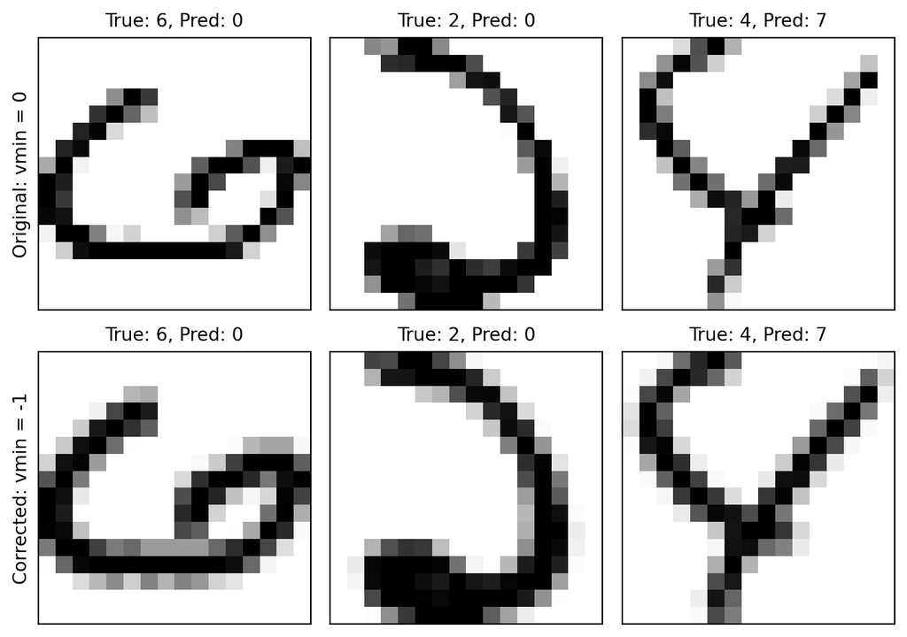

```python
zip_train = np.loadtxt("data/knn/zip-train.csv.gz", delimiter=",")
zip_test  = np.loadtxt("data/knn/zip-test.csv.gz",  delimiter=",")
X_train, y_train = zip_train[:1000, 1:], zip_train[:1000, 0].astype(int)
X_test,  y_test  = zip_test[:500, 1:],   zip_test[:500, 0].astype(int)
print("Pixel range:", X_test.min(), "to", X_test.max())

# Euclidean 5NN: distance ties -> smaller row, vote ties -> smaller digit
pred = np.zeros(len(X_test), dtype=int)
for i, x in enumerate(X_test):
    d = np.sqrt(np.sum((X_train - x)**2, axis=1))
    nn = np.argsort(d, kind="stable")[:5]
    pred[i] = np.argmax(np.bincount(y_train[nn], minlength=10))

incorrect = np.where(pred != y_test)[0][:3]

fig, axes = plt.subplots(2, 3, figsize=(7, 5))
for row, (vmin, lab) in enumerate([(0, "Original: vmin = 0"), (-1, "Corrected: vmin = -1")]):
    for ax, i in zip(axes[row], incorrect):
        ax.imshow(X_test[i].reshape(16, 16), cmap="gray_r", vmin=vmin, vmax=1)
        ax.set_title(f"True: {y_test[i]}, Pred: {pred[i]}", fontsize=10)
        ax.set_xticks([]); ax.set_yticks([])
    axes[row, 0].set_ylabel(lab, fontsize=10)
fig.tight_layout()
plt.show()
```

With the full −1 to 1 scale, the faint edges of each stroke appear in light gray instead of being cut to white. These are the pixel values the classifier actually uses in its distance calculation. The 6 now shows a thick, closed lower loop and a short top stroke, so a 0 prediction is understandable. The 2 has a heavy, rounded bottom, so a 0 prediction is also understandable. The 4 has an open top whose right arm runs up like the stroke of a 7. The predictions are unchanged, because only the display was wrong, but the corrected figure shows what KNN compared, so it better supports the claim that the mistakes are visually understandable.

**GitHub Issue:** https://github.com/gaoxinc2/stat432-fall2026/issues/3